## Máster en Data Science - Series Temporales

# BATS & TBATS Models

Autor: Ramón Morillo Barrera

## Dataset: Madrid.csv

Los modelos BATS (Box-Cox transformation, ARMA errors, Trend, and Seasonal components) y TBATS (Trigonometric BATS) son enfoques avanzados para el modelado y pronóstico de series temporales, diseñados específicamente para manejar datos con patrones complejos y estacionalidades múltiples. Ambos modelos combinan transformaciones, componentes de suavizado exponencial, errores ARMA y técnicas específicas para abordar irregularidades en los datos. En particular, TBATS extiende el enfoque de BATS al incluir funciones trigonométricas para representar estacionalidades no enteras o de alta frecuencia, lo que lo hace especialmente útil para series con estacionalidades complejas o múltiples.

Gracias a su flexibilidad y capacidad para integrar diferentes elementos en una estructura unificada, estos modelos son herramientas robustas para predecir series temporales con características que van más allá de lo que métodos tradicionales pueden manejar. Su aplicabilidad a datos con patrones irregulares y variabilidad significativa los convierte en una opción prometedora para la predicción de fenómenos complejos, como el comportamiento de pasajeros en sistemas de transporte público.

Hasta ahora hemos probado métodos de predicción sencilla, ARIMA, ETS, Theta y CES. Siendo los modelos ETS y Theta los que mejores resultados dieron hasta el momento.

```python
# librerías
import pandas as pd
import numpy as np
import matplotlib.pyplot as plt
from darts.metrics import mape, smape, mse, rmse
from darts.models import TBATS , BATS
from darts import TimeSeries

import warnings
warnings.filterwarnings('ignore')
```

### Importación de datos

```python
df_autobus_month = pd.read_csv('../data/processed/Madrid_autobus_month.csv', index_col='Periodo')
df_metro_month = pd.read_csv('../data/processed/Madrid_metro_month.csv', index_col='Periodo')
df_combined_month = pd.read_csv('../data/processed/Madrid_combined_month.csv', index_col='Periodo')

df_autobus_trim = pd.read_csv('../data/processed/Madrid_autobus_trim.csv', index_col='Periodo')
df_metro_trim = pd.read_csv('../data/processed/Madrid_metro_trim.csv', index_col='Periodo')
df_combined_trim = pd.read_csv('../data/processed/Madrid_combined_trim.csv', index_col='Periodo')
```

```python
df_autobus_month = df_autobus_month[ 'Total']
df_autobus_trim = df_autobus_trim['Total']
df_combined_month = df_combined_month[ 'Total']
df_combined_trim = df_combined_trim['Total']
df_metro_month = df_metro_month['Total']
df_metro_trim = df_metro_trim['Total']
```

```python
df_autobus_month.index = pd.to_datetime(df_autobus_month.index)
df_autobus_trim.index = pd.to_datetime(df_autobus_trim.index)
df_combined_month.index = pd.to_datetime(df_combined_month.index)
df_combined_trim.index = pd.to_datetime(df_combined_trim.index)
df_metro_month.index = pd.to_datetime(df_metro_month.index)
df_metro_trim.index = pd.to_datetime(df_metro_trim.index)

df_autobus_month = df_autobus_month.resample("M").last()
df_autobus_trim = df_autobus_trim.resample("QE").last()
df_combined_month = df_combined_month.resample("M").last()
df_combined_trim = df_combined_trim.resample("QE").last()
df_metro_month = df_metro_month.resample("M").last()
df_metro_trim = df_metro_trim.resample("QE").last()
```

## Modelo BATS

El modelo BATS es una extensión del enfoque de suavizado exponencial que permite modelar series temporales con componentes de tendencia, estacionalidad y errores autocorrelacionados. Utiliza la transformación de Box-Cox para estabilizar la varianza de los datos y permite capturar estacionalidades múltiples mediante la inclusión de diferentes tipos de componentes estacionales. Su principal ventaja es la capacidad para adaptarse a series temporales complejas, ofreciendo una solución flexible y eficaz para datos con variabilidad en la tendencia y la estacionalidad.

```python
df_autobus_month = TimeSeries.from_series(df_autobus_month)
df_autobus_trim = TimeSeries.from_series(df_autobus_trim)
df_combined_month = TimeSeries.from_series(df_combined_month)
df_combined_trim = TimeSeries.from_series(df_combined_trim)
df_metro_month = TimeSeries.from_series(df_metro_month)
df_metro_trim = TimeSeries.from_series(df_metro_trim)
```

### Series mensuales

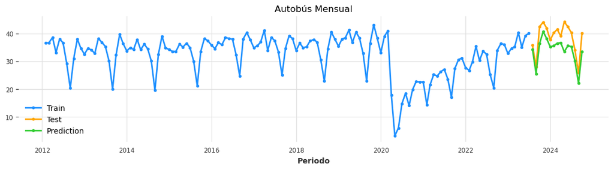

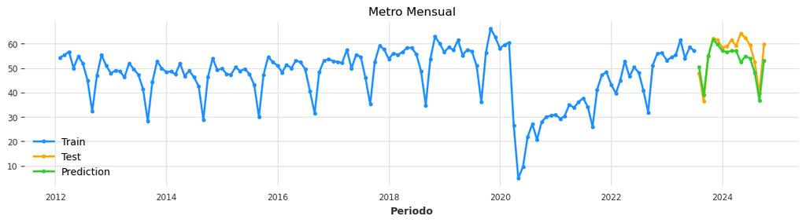

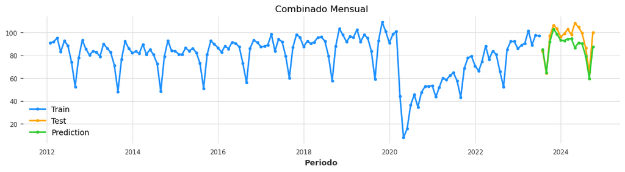

```python
def predict_with_bats(df, sp, test_size, title):
    # Split the data into train and test sets
    train, test = df[:-test_size], df[-test_size:]

    # Initialize and fit the BATS model
    model = BATS(use_trend=True,seasonal_periods=[sp])
    model.fit(train)

    # Make predictions
    prediction = model.predict(len(test))

    # Plot the results
    plt.figure(figsize=(14, 3))
    train.plot(label='Train', color='dodgerblue', marker='o', markersize=3)
    test.plot(label='Test', color='orange', marker='o', markersize=3)
    prediction.plot(label='Prediction', color='limegreen', marker='o', markersize=3)
    plt.legend()
    plt.title(f'{title}')
    plt.show()

# Realizar predicciones para los tres dataframes mensuales
predict_with_bats(df_autobus_month, 12, 15, 'Autobús Mensual')
predict_with_bats(df_metro_month, 12, 15, 'Metro Mensual')
predict_with_bats(df_combined_month, 12, 15, 'Combinado Mensual')
```

```python
def predict_with_bats_metrics(df, sp, test_size, title):
    # Split the data into train and test sets
    train, test = df[:-test_size], df[-test_size:]

    # Initialize and fit the BATS model
    model = BATS(use_trend=True, seasonal_periods=[sp])
    model.fit(train)

    # Make predictions
    prediction = model.predict(len(test))

    return test, prediction

# Realizar predicciones para los tres dataframes mensuales
test_autobus, pred_autobus = predict_with_bats_metrics(df_autobus_month, 12, 15, 'Autobús Mensual')
test_metro, pred_metro = predict_with_bats_metrics(df_metro_month, 12, 15, 'Metro Mensual')
test_combined, pred_combined = predict_with_bats_metrics(df_combined_month, 12, 15, 'Combinado Mensual')

# Calcular y mostrar las métricas
metrics = {
    'Autobús Mensual': (test_autobus, pred_autobus),
    'Metro Mensual': (test_metro, pred_metro),
    'Combinado Mensual': (test_combined, pred_combined)
}

for title, (test, pred) in metrics.items():
    mse_value = mse(test, pred)
    rmse_value = rmse(test, pred)
    mape_value = mape(test, pred)
    print(f'{title} - MSE: {mse_value:.2f}, RMSE: {rmse_value:.2f}, MAPE: {mape_value:.2f}%')
```

```
Autobús Mensual - MSE: 26.21, RMSE: 5.12, MAPE: 11.74%
Metro Mensual - MSE: 22.85, RMSE: 4.78, MAPE: 6.62%
Combinado Mensual - MSE: 77.65, RMSE: 8.81, MAPE: 7.20%
```

Los modelos BATS ofrecen unas predicciones mediocres en comparación a los modelos ETS y Theta, que son los que capturan mejor la tendencia y el componente estacional de la serie, no son malas métricas de evaluación pero hemos conseguido mejores resultados probando modelos anteriores. Por el momento, los modelos BATS quedan descartados para predecir nuestras series temporales mensuales.

### Series trimestrales

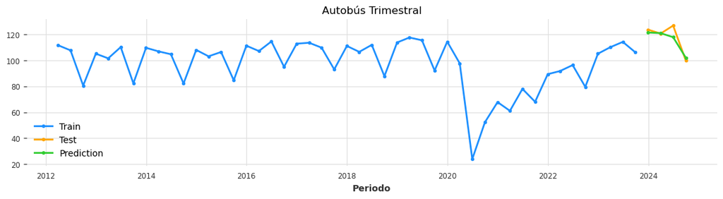

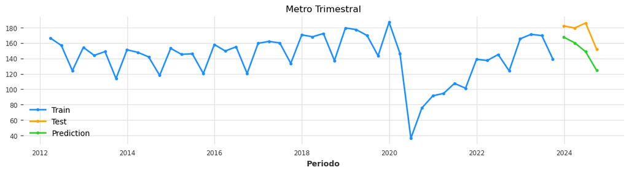

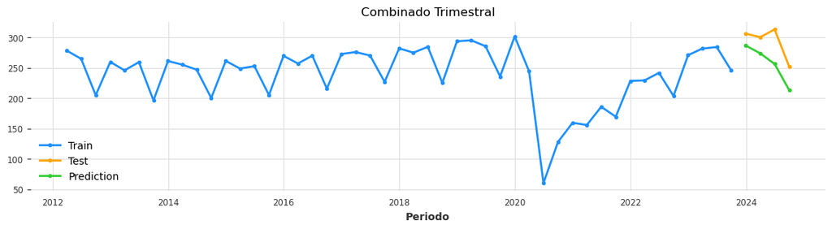

```python
predict_with_bats(df_autobus_trim, 4, 4, 'Autobús Trimestral')
predict_with_bats(df_metro_trim, 4, 4, 'Metro Trimestral')
predict_with_bats(df_combined_trim, 4, 4, 'Combinado Trimestral')
```

```python
# Realizar predicciones para los tres dataframes trimestrales
test_autobus_trim, pred_autobus_trim = predict_with_bats_metrics(df_autobus_trim, 4, 4, 'Autobús Trimestral')
test_metro_trim, pred_metro_trim = predict_with_bats_metrics(df_metro_trim, 4, 4, 'Metro Trimestral')
test_combined_trim, pred_combined_trim = predict_with_bats_metrics(df_combined_trim, 4, 4, 'Combinado Trimestral')

# Calcular y mostrar las métricas
metrics = {
    'Autobús Trimestral': (test_autobus_trim, pred_autobus_trim),
    'Metro Trimestral': (test_metro_trim, pred_metro_trim),
    'Combinado Trimestral': (test_combined_trim, pred_combined_trim)
}

for title, (test, pred) in metrics.items():
    mse_value = mse(test, pred)
    rmse_value = rmse(test, pred)
    mape_value = mape(test, pred)
    print(f'{title} - MSE: {mse_value:.2f}, RMSE: {rmse_value:.2f}, MAPE: {mape_value:.2f}%')
```

```
Autobús Trimestral - MSE: 22.49, RMSE: 4.74, MAPE: 2.82%
Metro Trimestral - MSE: 681.50, RMSE: 26.11, MAPE: 14.22%
Combinado Trimestral - MSE: 1453.65, RMSE: 38.13, MAPE: 12.19%
```

En cuanto a los resultados de predicción de las series trimestrales observamos lo mismo que en las mensuales, exceptuando la serie trimestral de pasajeros de autobús, la de metro y Combinado no obtienen resultados muy favorables.

## Modelo TBATS

El modelo TBATS (Trigonometric BATS) es una extensión del modelo BATS diseñada para capturar patrones estacionales más complejos y múltiples estacionalidades en series temporales. Incluye funciones trigonométricas para representar estacionalidades de alta frecuencia o no enteras, lo que lo hace especialmente útil en datos con variaciones estacionales irregulares o que cambian con el tiempo. Además, integra transformaciones de Box-Cox, errores ARMA, y componentes de tendencia y estacionalidad, ofreciendo una gran flexibilidad. Esta combinación permite al modelo TBATS adaptarse a una amplia variedad de series temporales con características complejas, proporcionando predicciones precisas y confiables.

Veremos si supera a las predicciones anteriores del modelo BATS.

### Series mensuales TBATS

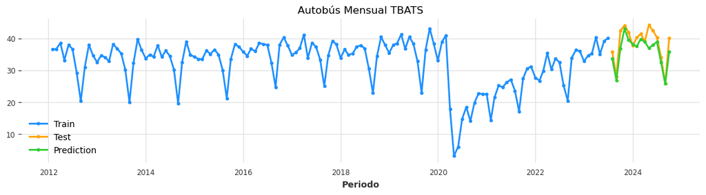

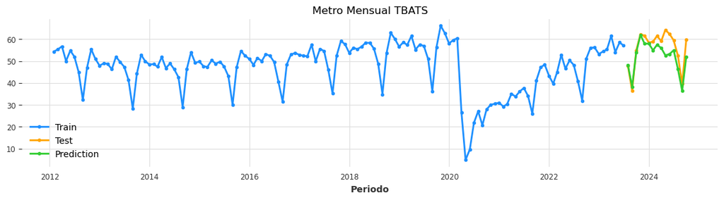

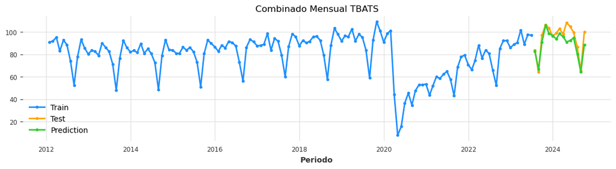

```python
def plot_predictions(df, sp, test_size, title):
    # Split the data into train and test sets
    train, test = df[:-test_size], df[-test_size:]

    # Initialize and fit the BATS model
    model = TBATS(use_trend=True,seasonal_periods=[sp],use_box_cox=True)
    model.fit(train)

    # Make predictions
    prediction = model.predict(len(test))

    # Plot the results
    plt.figure(figsize=(14, 3))
    train.plot(label='Train', color='dodgerblue', marker='o', markersize=3)
    test.plot(label='Test', color='orange', marker='o', markersize=3)
    prediction.plot(label='Prediction', color='limegreen', marker='o', markersize=3)
    plt.legend()
    plt.title(f'{title}')
    plt.show()

# Generar y graficar predicciones para los tres dataframes mensuales
plot_predictions(df_autobus_month, 12, 15, 'Autobús Mensual TBATS')
plot_predictions(df_metro_month, 12, 15, 'Metro Mensual TBATS')
plot_predictions(df_combined_month, 12, 15, 'Combinado Mensual TBATS')
```

```python
def predict_with_tbats_metrics(df, sp, test_size, title):
    # Split the data into train and test sets
    train, test = df[:-test_size], df[-test_size:]

    # Initialize and fit the TBATS model
    model = TBATS(use_trend=True, seasonal_periods=[sp], use_box_cox=True)
    model.fit(train)

    # Make predictions
    prediction = model.predict(len(test))

    return test, prediction

# Realizar predicciones para los tres dataframes mensuales
test_autobus_tbats, pred_autobus_tbats = predict_with_tbats_metrics(df_autobus_month, 12, 15, 'Autobús Mensual')
test_metro_tbats, pred_metro_tbats = predict_with_tbats_metrics(df_metro_month, 12, 15, 'Metro Mensual')
test_combined_tbats, pred_combined_tbats = predict_with_tbats_metrics(df_combined_month, 12, 15, 'Combinado Mensual')

# Calcular y mostrar las métricas
metrics_tbats = {
    'Autobús Mensual': (test_autobus_tbats, pred_autobus_tbats),
    'Metro Mensual': (test_metro_tbats, pred_metro_tbats),
    'Combinado Mensual': (test_combined_tbats, pred_combined_tbats)
}

for title, (test, pred) in metrics_tbats.items():
    mse_value = mse(test, pred)
    rmse_value = rmse(test, pred)
    mape_value = mape(test, pred)
    print(f'{title} - MSE: {mse_value:.2f}, RMSE: {rmse_value:.2f}, MAPE: {mape_value:.2f}%')
```

```
Autobús Mensual - MSE: 10.03, RMSE: 3.17, MAPE: 5.99%
Metro Mensual - MSE: 27.20, RMSE: 5.22, MAPE: 7.10%
Combinado Mensual - MSE: 50.66, RMSE: 7.12, MAPE: 5.39%
```

### Series trimestrales TBATS

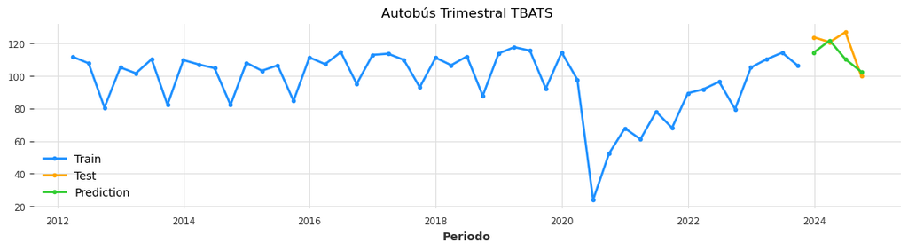

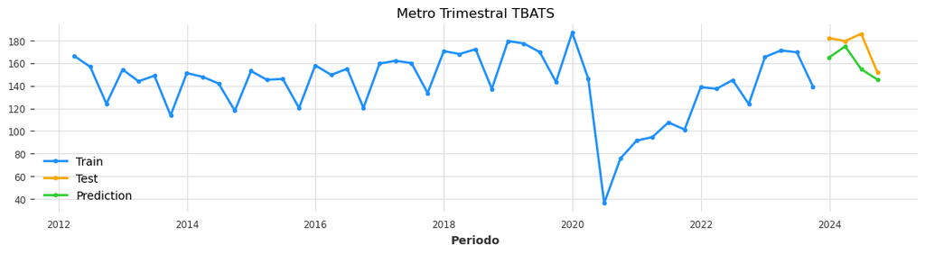

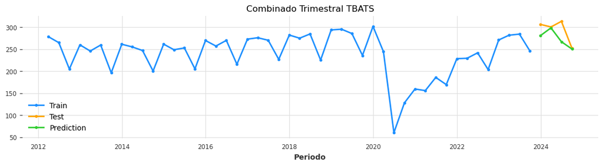

```python
plot_predictions(df_autobus_trim, 4, 4, 'Autobús Trimestral TBATS')
plot_predictions(df_metro_trim, 4, 4, 'Metro Trimestral TBATS')
plot_predictions(df_combined_trim, 4, 4, 'Combinado Trimestral TBATS')
```

```python
# Realizar predicciones para los tres dataframes trimestrales
test_autobus_tbats_trim, pred_autobus_tbats_trim = predict_with_tbats_metrics(df_autobus_trim, 4, 4, 'Autobús Trimestral')
test_metro_tbats_trim, pred_metro_tbats_trim = predict_with_tbats_metrics(df_metro_trim, 4, 4, 'Metro Trimestral')
test_combined_tbats_trim, pred_combined_tbats_trim = predict_with_tbats_metrics(df_combined_trim, 4, 4, 'Combinado Trimestral')

# Calcular y mostrar las métricas
metrics_tbats = {
    'Autobús Trimestral': (test_autobus_tbats_trim, pred_autobus_tbats_trim),
    'Metro Trimestral': (test_metro_tbats_trim, pred_metro_tbats_trim),
    'Combinado Trimestral': (test_combined_tbats_trim, pred_combined_tbats_trim)
}

for title, (test, pred) in metrics_tbats.items():
    mse_value = mse(test, pred)
    rmse_value = rmse(test, pred)
    mape_value = mape(test, pred)
    print(f'{title} - MSE: {mse_value:.2f}, RMSE: {rmse_value:.2f}, MAPE: {mape_value:.2f}%')
```

```
Autobús Trimestral - MSE: 92.94, RMSE: 9.64, MAPE: 6.04%
Metro Trimestral - MSE: 334.95, RMSE: 18.30, MAPE: 8.25%
Combinado Trimestral - MSE: 698.11, RMSE: 26.42, MAPE: 6.11%
```

En las series trimestrales de las predicciones del modelo TBATS ocurre lo mismo. Exceptuando la de autobús, las otras dos mejoran a BATS pero son inferiores a ETS y Theta.

## Conclusión BATS & TBATS

Los resultados obtenidos con los modelos BATS y TBATS muestran que, aunque son herramientas avanzadas y flexibles para el análisis de series temporales complejas, no lograron captar de manera adecuada la tendencia y estacionalidad características de las series de pasajeros de autobús y metro de Madrid. Esto se refleja en un desempeño inferior en comparación con los modelos ETS y Theta, que demostraron ser más precisos y confiables para estas series. Por lo tanto, se descarta el uso de BATS y TBATS para las predicciones en este contexto específico, privilegiando los modelos que han mostrado un mejor ajuste y resultados más consistentes en la representación de los patrones observados en los datos.